# **MATH 3190 Homework 3**

Due February 12, 2026  
Focus: Notes 5  
Total Points: 90 + 10 (Self-Critique Comment and Uploading to GitHub) = 100

Note that your homework should be completed in Quarto. You can just add your answers and code to this document in the appropriate part. The file should be rendered as an html document or pdf document (html is quicker to render and you will need an installation of LaTeX to render as a pdf). You will “turn in” this homework by uploading the files, the .qmd and output file, to your GitHub `Math_3190_Assignment` repository in the `Homework/Homework_3` directory. Make sure all supporting files (if there are any) are in this directory as well. You should use `git` and `Unix` commands in a terminal for this (i.e. don’t manually upload files to GitHub). In addition, you will submit just your html or pdf file on Canvas to unlock the solutions.

Don’t forget to also put a self-critique comment on Canvas indicating what you did correctly and incorrectly and include any questions you may have about the assignment after submitting the assignment and thoroughly looking through the solutions.

# Problem 1 (11 points)

### Part a (9 points)

Suppose we are attempting to predict a person’s ability to run a marathon in under 4 hours (coded as a 1) based on a number of factors: age, sex, BMI, and blood pressure. Below is the confusion matrix in this situation:

|  | **Actual: 1** | **Actual: 0** |
| --- | --- | --- |
| **Predicted: 1** | 58 | 102 |
| **Predicted: 0** | 37 | 217 |

Find each of the following. Use proper formatting in Quarto when you type your answers. You can put equations between dollar signs (`$$`) and you can use the `\frac{}{}` (for a small fraction) or `\dfrac{}{}` (for a larger one) commands to nicely type fractions.

$\text{Prevalence} = \dfrac{58 + 37}{414} = \dfrac{95}{414} \approx 0.2295$

- **The overall accuracy of these predictions**

$\text{Accuracy} = \dfrac{58 + 217}{414} = \dfrac{275}{414} \approx 0.6643$

- **The sensitivity (recall)**

$\text{Sensitivity} = \dfrac{58}{58 + 37} = \dfrac{58}{95} \approx 0.6105$

- **The specificity**

$\text{Specificity} = \dfrac{217}{217 + 102} = \dfrac{217}{319} \approx 0.6803$

- **The positive predictive value (precision)**

$\text{PPV} = \dfrac{58}{58 + 102} = \dfrac{58}{160} = 0.3625$

- **The negative predictive value**

$\text{NPV} = \dfrac{217}{217 + 37} = \dfrac{217}{254} \approx 0.8543$

- **The balanced accuracy**

$\text{Balanced Accuracy} = \dfrac{0.6105 + 0.6803}{2} \approx 0.6454$

- **Cohen’s Kappa ($\kappa$).** Check out this link on [Wikipedia: Cohen’s Kappa](https://en.wikipedia.org/wiki/Cohen%27s_kappa) and scroll down to the section entitled **Binary classification confusion matrix**.

$p_o = 0.6643$  
$p_e = \dfrac{(95 \times 160) + (319 \times 254)}{414^2} \approx 0.5614$  
$\kappa = \dfrac{p_o - p_e}{1 - p_e} = \dfrac{0.6643 - 0.5614}{1 - 0.5614} \approx 0.2346$

- F1 score. Check out what this is on [Wikipedia: F-Score](https://en.wikipedia.org/wiki/F-score)

$\text{F1} = 2 \times \dfrac{0.3625 \times 0.6105}{0.3625 + 0.6105} \approx 0.4549$

### Part b (2 points)

Read more of the Wikipedia article on Cohen’s Kappa, especially the **Interpreting magnitude** and the **Limitations** part. I cannot really verify that you did this, so this is on your honor.

# Problem 2 (79 points)

The `adult` dataset (from the UC Irvine [database](https://archive.ics.uci.edu/dataset/2/adult)) is one that is used to predict whether a person makes over $50K a year based on some other variables. The data came from the Census Bureau in 1994 and can be found in the Data folder in my Math3190_S26 GitHub repo. More info on the dataset can be found in the “adult.names” file.

### Part a (4 points)

Read the data into **R** as a tibble, change the column names to be descriptive about what the variable in that column is, and change the one containing salary information to a factor. Read the “adult.names” file to see the column names. Note that even though this file has a `.data.` suffix, it is comma separated, so you can read it in using `read.csv()` in base **R** and the convert it to a tibble or `read_csv()` from the tidyverse, which wil read it in as a tibble.

```r
library(tidyverse)
library(ggplot2)

# Set column names
adult_colnames <- c(
  "age", "workclass", "fnlwgt", "education", "education_num",
  "marital_status", "occupation", "relationship", "race", "sex",
  "capital_gain", "capital_loss", "hours_per_week", "native_country",
  "income"
)

# read in data
adult = read_csv("adult.data", col_names = adult_colnames) |>
  mutate(
    income = as.factor(str_trim(income)),
    across(where(is.character), str_trim)
  )
head(adult)
```

```
# A tibble: 6 × 15
    age workclass       fnlwgt education education_num marital_status occupation
  <dbl> <chr>            <dbl> <chr>             <dbl> <chr>          <chr>
1    39 State-gov        77516 Bachelors            13 Never-married  Adm-cleri…
2    50 Self-emp-not-i…  83311 Bachelors            13 Married-civ-s… Exec-mana…
3    38 Private         215646 HS-grad               9 Divorced       Handlers-…
4    53 Private         234721 11th                  7 Married-civ-s… Handlers-…
5    28 Private         338409 Bachelors            13 Married-civ-s… Prof-spec…
6    37 Private         284582 Masters              14 Married-civ-s… Exec-mana…
# ℹ 8 more variables: relationship <chr>, race <chr>, sex <chr>,
#   capital_gain <dbl>, capital_loss <dbl>, hours_per_week <dbl>,
#   native_country <chr>, income <fct>
```

### Part b (4 points)

```r
library(caret)
```

```r
set.seed(123)
train_index <- createDataPartition(adult$income, p = 0.80, list = FALSE)

adult_train <- adult[train_index, ]
adult_test  <- adult[-train_index, ]
```

### Part c (5 points)

Fit two models for predicting whether a person’s salary is above $50K or not:

For the first model, fit a logistic regression model using something like `glm(salary ~ age + education + race + sex + hours_per_week, data = adult_train, family = "binomial")`. By the way, if you are unfamiliar with logistic regression, take some time to research it online or in my notes from Math 3150, which you can find [here](https://drive.google.com/file/d/1qQajPxb9tdgx5Qal-ppsK18XEdzsXe1o/view?usp=sharing). We will deal with logistic regression again on the next homework. You don’t need to know everything about it, just learn a little about how it is used to predict the class for an observation. Of course, I’m happy to explain how it works in office hours as well.

```r
log_adult <- glm(income ~ age + education + race + sex + hours_per_week, data = adult_train,
                 family = "binomial")

summary(log_adult)
```

```
Call:
glm(formula = income ~ age + education + race + sex + hours_per_week,
    family = "binomial", data = adult_train)

Coefficients:
                        Estimate Std. Error z value Pr(>|z|)
(Intercept)            -7.518779   0.230908 -32.562  < 2e-16 ***
age                     0.044825   0.001091  41.088  < 2e-16 ***
education11th           0.151673   0.182212   0.832  0.40518
education12th           0.642514   0.220076   2.920  0.00351 **
education1st-4th       -0.785507   0.388019  -2.024  0.04293 *
education5th-6th       -0.142043   0.249816  -0.569  0.56963
education7th-8th       -0.616116   0.213105  -2.891  0.00384 **
education9th           -0.137470   0.226262  -0.608  0.54347
educationAssoc-acdm     1.921465   0.149071  12.890  < 2e-16 ***
educationAssoc-voc      1.911668   0.145006  13.183  < 2e-16 ***
educationBachelors      2.588053   0.135187  19.144  < 2e-16 ***
educationDoctorate      3.438641   0.171767  20.019  < 2e-16 ***
educationHS-grad        1.194019   0.134436   8.882  < 2e-16 ***
educationMasters        2.985988   0.140512  21.251  < 2e-16 ***
educationPreschool     -1.506712   1.020549  -1.476  0.13984
educationProf-school    3.500804   0.161689  21.651  < 2e-16 ***
educationSome-college   1.616960   0.135414  11.941  < 2e-16 ***
raceAsian-Pac-Islander  0.434059   0.187156   2.319  0.02038 *
raceBlack               0.031598   0.180394   0.175  0.86095
raceOther               0.056899   0.259462   0.219  0.82642
raceWhite               0.537068   0.172174   3.119  0.00181 **
sexMale                 1.148558   0.034669  33.129  < 2e-16 ***
hours_per_week          0.034164   0.001169  29.230  < 2e-16 ***
---
Signif. codes:  0 '***' 0.001 '**' 0.01 '*' 0.05 '.' 0.1 ' ' 1

(Dispersion parameter for binomial family taken to be 1)

    Null deviance: 43002  on 39073  degrees of freedom
Residual deviance: 33389  on 39051  degrees of freedom
AIC: 33435

Number of Fisher Scoring iterations: 6
```

For the second model, fit a $k$ nearest neighbors model with $k=7$ neighbors using the `knn3()` function in the `caret` package. Again, use `age`, `education`, `race`, `sex`, and `hours_per_week` as the predictors.

```r
knn_adult <- knn3(income ~ age + education + race + sex + hours_per_week, data = adult_train,
                  k = 7)
knn_adult
```

```
7-nearest neighbor model
Training set outcome distribution:

<=50K  >50K
29724  9350
```

### Part d (5 points)

With logistic regression, the most common cutoff value for the predicted probability for predicting a “success” is 0.5. Using 0.5 as this cutoff (above 0.5 should be labeled as “>50K”), obtain the class predictions and convert the variable to a factor. You can use the `predict()` function with `type = "response"` to obtain the predicted probabilities of being in the “>50K” group and then compare those probabilities to 0.5. Then use the `confusionMatrix()` function in the `caret` package to obtain the confusion matrix and many associated statistics. Print all of the output from that function. Remember to use the `positive` argument in that function. The positive should be the `>50K` category.

```r
log_probs <- predict(log_adult, newdata = adult_test, type = "response")

# Use ifelse to check the whole vector at once. Pretty Handy
log_preds <- ifelse(log_probs > 0.5, ">50K", "<=50K") |> factor(levels = c("<=50K", ">50K"))

# Confusion matrix
confusionMatrix(data = log_preds, reference = adult_test$income, positive = ">50K")
```

```
Confusion Matrix and Statistics

          Reference
Prediction <=50K >50K
     <=50K  6935 1452
     >50K    496  885

               Accuracy : 0.8006
                 95% CI : (0.7925, 0.8085)
    No Information Rate : 0.7607
    P-Value [Acc > NIR] : < 2.2e-16

                  Kappa : 0.3628

 Mcnemar's Test P-Value : < 2.2e-16

            Sensitivity : 0.3787
            Specificity : 0.9333
         Pos Pred Value : 0.6408
         Neg Pred Value : 0.8269
             Prevalence : 0.2393
         Detection Rate : 0.0906
   Detection Prevalence : 0.1414
      Balanced Accuracy : 0.6560

       'Positive' Class : >50K
```

### Part e (4 points)

Obtain the class predictions for your kNN model and output the results of the `confusionMatrix()` function for this. Note that it will take a few seconds to obtain the predictions for the kNN model.

```r
knn_probs <- predict(knn_adult, newdata = adult_test, type = "prob")

# ifelse
knn_preds <- ifelse(knn_probs[, ">50K"] > 0.5, ">50K", "<=50K") |> factor(levels = c("<=50K", ">50K"))

# Confusion Matrix
knn_cm <- confusionMatrix(data = knn_preds, reference = adult_test$income, positive = ">50K")

# Print results
print(knn_cm)
```

```
Confusion Matrix and Statistics

          Reference
Prediction <=50K >50K
     <=50K  6802 1434
     >50K    629  903

               Accuracy : 0.7888
                 95% CI : (0.7806, 0.7969)
    No Information Rate : 0.7607
    P-Value [Acc > NIR] : 2.406e-11

                  Kappa : 0.3421

 Mcnemar's Test P-Value : < 2.2e-16

            Sensitivity : 0.38639
            Specificity : 0.91535
         Pos Pred Value : 0.58943
         Neg Pred Value : 0.82589
             Prevalence : 0.23925
         Detection Rate : 0.09244
   Detection Prevalence : 0.15684
      Balanced Accuracy : 0.65087

       'Positive' Class : >50K
```

### Part f (4 points)

Using the output from parts d and e, write a few sentences comparing and contrasting the strengths and weaknesses of each model when it comes to predictions.

### Part g (8 points)

Using the `train()` function in the `caret` package, perform 5-fold cross validation for $k$ in the kNN model using only the training set and again using `age`, `education`, `race`, `sex`, and `hours_per_week` as the predictors. Set the search for $k$ to be from 1 to 21 (we’ll stop at 21 to save time) in the `tuneGrid` argument. Make sure to use the `trControl` option to set it to cross validation. Then use Cohen’s $\kappa$ as the metric to determine the best $k$ value. You can change the metric in the `train()` function to Cohen’s $\kappa$ by putting in `metric = "Kappa"`.

```r
# Define the Cross-Validation control
ctrl <- trainControl(method = "cv", number = 5)

# Define the search grid for k
k_grid <- expand.grid(k = seq(1, 21, by = 2))

# Train the model using Kappa as the selection metric
knn_tuned <- train(
  income ~ age + education + race + sex + hours_per_week,
  data = adult_train,
  method = "knn",
  trControl = ctrl,
  tuneGrid = k_grid,
  metric = "Kappa"
)

# Print the results to see the best k
print(knn_tuned)
```

```
k-Nearest Neighbors

39074 samples
    5 predictor
    2 classes: '<=50K', '>50K'

No pre-processing
Resampling: Cross-Validated (5 fold)
Summary of sample sizes: 31259, 31260, 31259, 31259, 31259
Resampling results across tuning parameters:

  k   Accuracy   Kappa
   1  0.7709218  0.3286819
   3  0.7777550  0.3281496
   5  0.7815427  0.3307185
   7  0.7822849  0.3270580
   9  0.7832574  0.3235244
  11  0.7847929  0.3256259
  13  0.7845626  0.3223418
  15  0.7842555  0.3176696
  17  0.7841787  0.3146319
  19  0.7847417  0.3134135
  21  0.7846138  0.3124080

Kappa was used to select the optimal model using the largest value.
The final value used for the model was k = 5.
```

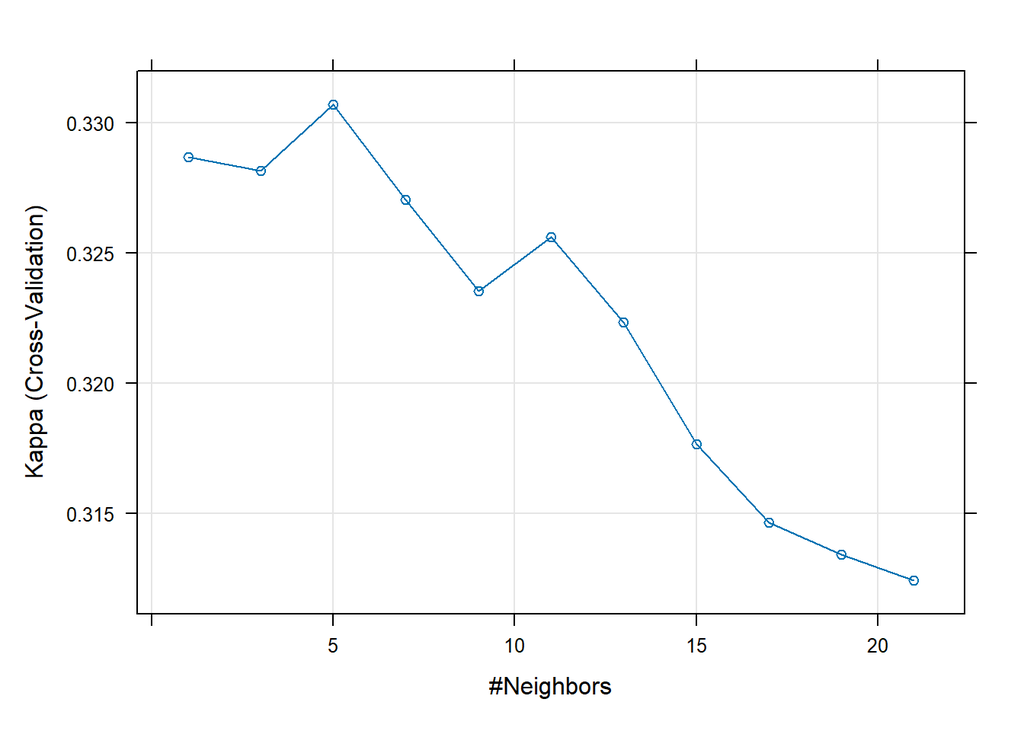

```r
plot(knn_tuned)
```

Then, if the best $k$ is different than 7, fit another kNN model with the optimal $k$ value. **Please set a seed at the beginning of this code chunk**.

```r
# Set seed
set.seed(123)

# Fit the kNN model with the optimal k = 5
knn_optimal_mod <- knn3(income ~ age + education + race + sex + hours_per_week,
                        data = adult_train, k = 5)

# Obtain class predictions on the test set
knn_opt_preds <- predict(knn_optimal_mod, newdata = adult_test, type = "class")

# Generate the confusion matrix using caret
knn_opt_cm <- confusionMatrix(data = knn_opt_preds, reference = adult_test$income,
                              positive = ">50K")

# Print
print(knn_opt_cm)
```

```
Confusion Matrix and Statistics

          Reference
Prediction <=50K >50K
     <=50K  6728 1359
     >50K    703  978

               Accuracy : 0.7889
                 95% CI : (0.7807, 0.797)
    No Information Rate : 0.7607
    P-Value [Acc > NIR] : 2.042e-11

                  Kappa : 0.3584

 Mcnemar's Test P-Value : < 2.2e-16

            Sensitivity : 0.4185
            Specificity : 0.9054
         Pos Pred Value : 0.5818
         Neg Pred Value : 0.8320
             Prevalence : 0.2393
         Detection Rate : 0.1001
   Detection Prevalence : 0.1721
      Balanced Accuracy : 0.6619

       'Positive' Class : >50K
```

It is fairly computationally expensive to optimize the $k$ for the kNN model here since it takes so long to obtain the predictions. So, this may take a few minutes to run. Note that you can add `#| cache: true` to the top of the code chunk to cache the output of the code so the code doesn’t need to run each time you render the document.

### Part h (20 points)

We mentioned the most common cutoff value for the predicted probability for predicting a “success” in logistic regression is 0.5. However, we can adjust this value to make it easier or more difficult to predict a success. Let’s optimize this cutoff value using 5-fold cross validation. Note: we could also do this with kNN, but we will not on this assignment.

Using the cutoff values from 0.15 to 0.85 by 0.05 (0.15, 0.20, 0.25, and so on up to 0.85) for predicting whether an adult has a salary above 50K, find which one performs best on the training set using the metric of Cohen’s $\kappa$, which is given in the output of the `confusionMatrix()` function. You will need a couple loops here since the `train()` function cannot do this for us. Note: you can find the indices of the rows in each fold using the `createFolds()` function in the `caret` library. Please set a seed at the beginning of your code chunk for this part.

```r
# Setup
set.seed(123)
thresholds <- seq(0.15, 0.85, by = 0.05)
folds <- createFolds(adult_train$income, k = 5)
results <- data.frame(threshold = thresholds, avg_kappa = 0)

# Outer loop for thresholds, inner loop for CV folds (matrices?)
for (i in seq_along(thresholds)) {
  thresh <- thresholds[i]
  kappa_values <- c()

  for (j in seq_along(folds)) {
    # Split data into fold-train and fold-validation
    cv_train <- adult_train[-folds[[j]], ]
    cv_val   <- adult_train[folds[[j]], ]

    # Fit model on cv_train
    fit <- glm(income ~ age + education + race + sex + hours_per_week,
               data = cv_train, family = "binomial")

    # Predict probabilities on cv_val
    probs <- predict(fit, newdata = cv_val, type = "response")

    # Apply current threshold
    preds <- ifelse(probs > thresh, ">50K", "<=50K") |>
             factor(levels = c("<=50K", ">50K"))

    # Calculate Kappa
    cm <- confusionMatrix(preds, cv_val$income, positive = ">50K")
    kappa_values[j] <- cm$overall["Kappa"]
  }

  # Store average Kappa for this threshold
  results$avg_kappa[i] <- mean(kappa_values)
}
```

```r
# Didn't want to reset my cache
best_row <- results[which.max(results$avg_kappa), ]
print(best_row)
```

```
  threshold avg_kappa
5      0.35 0.4197232
```

### Part i (5 points)

Once you have your “optimal” cutoff value, repeat part d using this cutoff and compare the results of this output to the results of the output for a kNN model with the optimal $k$ value you found in part g. For which statistics is the logistic regression better now and for which is it worse?

```r
# Optimal Value
optimal <- 0.35
log_probs <- predict(log_adult, newdata = adult_test, type = "response")

# Use ifelse to check the whole vector at once. Pretty Handy
log_preds <- ifelse(log_probs > optimal, ">50K", "<=50K") |> factor(levels = c("<=50K", ">50K"))

# Confusion matrix
confusionMatrix(data = log_preds, reference = adult_test$income, positive = ">50K")
```

```
Confusion Matrix and Statistics

          Reference
Prediction <=50K >50K
     <=50K  6308  966
     >50K   1123 1371

               Accuracy : 0.7861
                 95% CI : (0.7779, 0.7942)
    No Information Rate : 0.7607
    P-Value [Acc > NIR] : 1.401e-09

                  Kappa : 0.4257

 Mcnemar's Test P-Value : 0.0006422

            Sensitivity : 0.5866
            Specificity : 0.8489
         Pos Pred Value : 0.5497
         Neg Pred Value : 0.8672
             Prevalence : 0.2393
         Detection Rate : 0.1404
   Detection Prevalence : 0.2553
      Balanced Accuracy : 0.7178

       'Positive' Class : >50K
```

### Part j (15 points)

Finally, let’s test our two models (the logistic model with the “optimal” cutoff and the kNN model with the “optimal” $k$) on the test set. We must keep a few things in mind:

1. We must use the exact models we fit to the training set. We aren’t fitting new models here, we are just getting predictions from the test set using these models we already fit. You fit the logistic regression model in part c (with the best cutoff probability determined in part h) and you fit the kNN model in either part c or part g.
2. We should not use the results of the testing predictions to change our models. That should have been done with the training sets.

Find the predictions for the test set using both models, print the output of the `confusionMatrix()` function for each model, and compare the results in a few sentences.

```r
# --- Logistic Regression ---
# Using the threshold of 0.35 optimized in Part H
log_probs_test <- predict(log_adult, newdata = adult_test, type = "response")
log_preds_final <- ifelse(log_probs_test > 0.35, ">50K", "<=50K") |>
                    factor(levels = c("<=50K", ">50K"))

log_cm_final <- confusionMatrix(data = log_preds_final,
                                reference = adult_test$income,
                                positive = ">50K")

# --- OPTIMAL kNN (k = 5) ---
# Using the refit model from Part G
knn_preds_test <- predict(knn_optimal_mod, newdata = adult_test, type = "class")

# Ensuring levels are explicit to avoid "levels mismatch" errors
knn_preds_final <- factor(knn_preds_test, levels = c("<=50K", ">50K"))

knn_cm_final <- confusionMatrix(data = knn_preds_final,
                                reference = adult_test$income,
                                positive = ">50K")

# --- PRINT RESULTS ---
cat("--- FINAL LOGISTIC REGRESSION (Threshold = 0.35) ---\n")
```

```
--- FINAL LOGISTIC REGRESSION (Threshold = 0.35) ---
```

```r
print(log_cm_final)
```

```
Confusion Matrix and Statistics

          Reference
Prediction <=50K >50K
     <=50K  6308  966
     >50K   1123 1371

               Accuracy : 0.7861
                 95% CI : (0.7779, 0.7942)
    No Information Rate : 0.7607
    P-Value [Acc > NIR] : 1.401e-09

                  Kappa : 0.4257

 Mcnemar's Test P-Value : 0.0006422

            Sensitivity : 0.5866
            Specificity : 0.8489
         Pos Pred Value : 0.5497
         Neg Pred Value : 0.8672
             Prevalence : 0.2393
         Detection Rate : 0.1404
   Detection Prevalence : 0.2553
      Balanced Accuracy : 0.7178

       'Positive' Class : >50K
```

```r
cat("\n--- FINAL kNN (k = 5) ---\n")
```

```
--- FINAL kNN (k = 5) ---
```

```r
print(knn_cm_final)
```

```
Confusion Matrix and Statistics

          Reference
Prediction <=50K >50K
     <=50K  6717 1355
     >50K    714  982

               Accuracy : 0.7882
                 95% CI : (0.7799, 0.7963)
    No Information Rate : 0.7607
    P-Value [Acc > NIR] : 6.373e-11

                  Kappa : 0.3577

 Mcnemar's Test P-Value : < 2.2e-16

            Sensitivity : 0.4202
            Specificity : 0.9039
         Pos Pred Value : 0.5790
         Neg Pred Value : 0.8321
             Prevalence : 0.2393
         Detection Rate : 0.1005
   Detection Prevalence : 0.1736
      Balanced Accuracy : 0.6621

       'Positive' Class : >50K
```

### Part k (5 points)

Even though one method may be better on a given dataset than another, that does not mean that method will always predict better. However, logistic regression has a few advantages over kNN regardless of predictive power. List at least three advantages logistic regression has over kNN.

- Logistic regression is a supervised learning model instead of unsupervised
- Logistic regression is not as nearly computationaly expensive
- Knn is controlled by discete neighbors, whereas logistic regression has a continuos threshold